# Proceso de segmentación

Alejandro Bedoya - Sebastián Agudelo

Mateo Espinal - Juan Fernando Patiño

Estefanía Echeverry

Julio - 2021

# 1. Pasos previos a la segmentación

## 1.1. Se cargan las librerías necesarias

```r
library(dplyr)          #Para manipulación y limpieza de datos
library(knitr)          #Para mejorar visualmente las tablas
library(kableExtra)     #Para complementar los resultados de knitr
library(ggplot2)        #Para la creación y visualización de gráficos
library(cluster)        #Para la creación de grupos
library(factoextra)     #Para el análisis de clusters
options(scipen = 999)   #Visualización completa de cantidades numéricas grandes
```

## 1.2. Lectura de la base de datos

```r
#Se carga la base de datos
datos_originales <- read.csv("./datos/base_trabajo_segmentacion.csv",
                             sep = ";")

#Se imprime la cabecera
kable(head(datos_originales), "html", align = "c") %>%
    kable_paper("hover", full_width = F) %>%
    row_spec(0, background = "#327CCF", color = "white")%>%
    scroll_box(width = "100%") %>%
    kable_styling(bootstrap_options = c("hover", "condensed"))
```

| nit | en_vm_canal1 | en_vm_canal2 | en_vm_canal3 | en_vm_canal4 | en_vm_canal5 | en_vm_canal6 | en_vm_canal7 | en_vm_canal8 | en_vm_canal9 | en_vm_canal10 | en_vm_otros | en_tx_canal1 | en_tx_canal2 | en_tx_canal3 | en_tx_canal4 | en_tx_canal5 | en_tx_canal6 | en_tx_canal7 | en_tx_canal8 | en_tx_canal9 | en_tx_canal10 | en_tx_otros | sal_vm_canal5 | sal_vm_canal2 | sal_vm_canal8 | sal_vm_otros | sal_tx_canal5 | sal_tx_canal2 | sal_tx_canal8 | … |
| --- | --- | --- | --- | --- | --- | --- | --- | --- | --- | --- | --- | --- | --- | --- | --- | --- | --- | --- | --- | --- | --- | --- | --- | --- | --- | --- | --- | --- | --- | --- |
| C4936394968152386565 | 0 | 0 | 0 | 0 | 0 | 0 | 0 | 0 | 0 | 0 | 0 | 0.000000 | 0.000000 | 0.000000 | 0.00000 | 0.000000 | 0.00 | 0.00 | 0.0 | 0 | 0 | 0 | 0 | 0 | 0 | 0 | 0.000000 | 0.00000 | 0 | … |
| C-8615176103348111575 | 0 | 0 | 0 | 0 | 0 | 0 | 0 | 0 | 0 | 0 | 0 | 0.000000 | 0.000000 | 0.000000 | 0.00000 | 0.000000 | 0.00 | 0.00 | 0.0 | 0 | 0 | 0 | 0 | 0 | 0 | 0 | 0.000000 | 0.00000 | 0 | … |
| C2364605246729357060 | 250927493 | 54160892 | 5122152 | 41852510 | 413614315 | 1663236 | 2106847525 | 0 | 0 | 0 | 0 | 24.416667 | 11.916667 | 3.333333 | 237.83333 | 2.545454 | 5.40 | 8.25 | 0.0 | 0 | 0 | 0 | 413614315 | 2265361194 | 0 | 0 | 2.545454 | 613.08333 | 0 | … |
| C7393816976826597531 | 39402360 | 96468998 | 8226710 | 0 | 0 | 7072802 | 0 | 9000000 | 0 | 0 | 0 | 14.416667 | 13.833333 | 4.600000 | 0.00000 | 0.000000 | 2.80 | 0.00 | 1.0 | 0 | 0 | 0 | 0 | 60558440 | 0 | 0 | 0.000000 | 10.33333 | 0 | … |
| C872645851723947566 | 337432319 | 234217927 | 105344054 | 15755287 | 0 | 23671840 | 0 | 3600962 | 3727299 | 0 | 0 | 153.583333 | 42.250000 | 102.416667 | 49.33333 | 0.000000 | 18.00 | 0.00 | 2.2 | 4 | 0 | 0 | 0 | 0 | 0 | 622080714 | 0.000000 | 0.00000 | 0 | … |
| C-3870380727390720970 | 33629514 | 42883291 | 1348792 | 0 | 0 | 3828360 | 0 | 0 | 687244 | 0 | 0 | 7.416667 | 8.833333 | 1.000000 | 0.00000 | 0.000000 | 1.25 | 0.00 | 0.0 | 1 | 0 | 0 | 0 | 1960611436 | 0 | 0 | 0.000000 | 90.00000 | 0 | … |

## 1.3. Limpieza de datos

Dado que algunos datos de la variable $nit$ contienen un guión se procede a eliminarlo.

```r
#Se elimina el guión del nit
datos_originales$nit <- gsub("-","", datos_originales$nit)

#Se muestra la cabecera con el cambio realizado
kable(head(datos_originales), "html", align = "c") %>%
    kable_paper("hover", full_width = F) %>%
    row_spec(0, background = "#327CCF", color = "white")%>%
    scroll_box(width = "100%") %>%
    kable_styling(bootstrap_options = c("hover", "condensed"))
```

| nit | en_vm_canal1 | en_vm_canal2 | en_vm_canal3 | en_vm_canal4 | en_vm_canal5 | en_vm_canal6 | en_vm_canal7 | en_vm_canal8 | en_vm_canal9 | en_vm_canal10 | en_vm_otros | en_tx_canal1 | en_tx_canal2 | en_tx_canal3 | en_tx_canal4 | en_tx_canal5 | en_tx_canal6 | en_tx_canal7 | en_tx_canal8 | en_tx_canal9 | en_tx_canal10 | en_tx_otros | sal_vm_canal5 | sal_vm_canal2 | sal_vm_canal8 | sal_vm_otros | sal_tx_canal5 | sal_tx_canal2 | sal_tx_canal8 | … |
| --- | --- | --- | --- | --- | --- | --- | --- | --- | --- | --- | --- | --- | --- | --- | --- | --- | --- | --- | --- | --- | --- | --- | --- | --- | --- | --- | --- | --- | --- | --- |
| C4936394968152386565 | 0 | 0 | 0 | 0 | 0 | 0 | 0 | 0 | 0 | 0 | 0 | 0.000000 | 0.000000 | 0.000000 | 0.00000 | 0.000000 | 0.00 | 0.00 | 0.0 | 0 | 0 | 0 | 0 | 0 | 0 | 0 | 0.000000 | 0.00000 | 0 | … |
| C8615176103348111575 | 0 | 0 | 0 | 0 | 0 | 0 | 0 | 0 | 0 | 0 | 0 | 0.000000 | 0.000000 | 0.000000 | 0.00000 | 0.000000 | 0.00 | 0.00 | 0.0 | 0 | 0 | 0 | 0 | 0 | 0 | 0 | 0.000000 | 0.00000 | 0 | … |
| C2364605246729357060 | 250927493 | 54160892 | 5122152 | 41852510 | 413614315 | 1663236 | 2106847525 | 0 | 0 | 0 | 0 | 24.416667 | 11.916667 | 3.333333 | 237.83333 | 2.545454 | 5.40 | 8.25 | 0.0 | 0 | 0 | 0 | 413614315 | 2265361194 | 0 | 0 | 2.545454 | 613.08333 | 0 | … |
| C7393816976826597531 | 39402360 | 96468998 | 8226710 | 0 | 0 | 7072802 | 0 | 9000000 | 0 | 0 | 0 | 14.416667 | 13.833333 | 4.600000 | 0.00000 | 0.000000 | 2.80 | 0.00 | 1.0 | 0 | 0 | 0 | 0 | 60558440 | 0 | 0 | 0.000000 | 10.33333 | 0 | … |
| C872645851723947566 | 337432319 | 234217927 | 105344054 | 15755287 | 0 | 23671840 | 0 | 3600962 | 3727299 | 0 | 0 | 153.583333 | 42.250000 | 102.416667 | 49.33333 | 0.000000 | 18.00 | 0.00 | 2.2 | 4 | 0 | 0 | 0 | 0 | 0 | 622080714 | 0.000000 | 0.00000 | 0 | … |
| C3870380727390720970 | 33629514 | 42883291 | 1348792 | 0 | 0 | 3828360 | 0 | 0 | 687244 | 0 | 0 | 7.416667 | 8.833333 | 1.000000 | 0.00000 | 0.000000 | 1.25 | 0.00 | 0.0 | 1 | 0 | 0 | 0 | 1960611436 | 0 | 0 | 0.000000 | 90.00000 | 0 | … |

**Se remueven los nit duplicados del conjunto de datos**

Previamente se observó que cada registro pertenece a un cliente, por lo cual resulta extraña la presencia de nit duplicados, en la construcción de esta propuesta se tomó la decisión de eliminarlos.

```r
#Se identifica mediante booleanos la posición de los nit duplicados
duplicados <- duplicated(datos_originales$nit)

#Se almacenan los nit duplicados
nit_duplicados <- datos_originales[duplicados, "nit"]

#Se eliminan los nit duplicados del conjuntos de datos
datos_originales <- datos_originales %>% filter(!(nit %in% nit_duplicados))
```

**Se establece el nit como indice para cada fila**

```r
#Se establece el nit como indice para cada fila
row.names(datos_originales) <- datos_originales$nit
#Se elimina la columna nit
datos_originales <- datos_originales %>%  select(!matches("nit"))
```

# 2. Refactorización y creación de nuevas variables

Con el objetivo de determinar cuáles canales son usados por cada usuario, la magnitud monetaria y el número de transacciones que realiza cada cliente, se tomó la decisión de crear las siguientes variables a partir del conjunto de datos original:

1. Para cada canal de entrada se creará una nueva variable, estableciendo el valor de $(1)$ si el canal es usado por el cliente y $(0)$ en caso contrario.
2. Se creará una nueva variable donde se almacenará el valor total del ticket promedio de entrada para cada cliente a partir de la suma de todas las variables de tipo `en_vm`.
3. Se creará una nueva variable donde se almacenará el número total de transacciones de entrada para cada cliente a partir de la suma de tados las variables de tipo `en_tx`.

Lo anterior nos permitirá reducir la dimensionalidad, eliminar la correlación entre las variables de ticket promedio y de transacciones, establecer la tendencia de uso de cada canal y nos ayudará a comprender el volumen monetario y transaccional que representa cada cliente para la organización solicitante.

**Nota:** el mismo procedimiento se aplicará para las variables de salida.

## 2.1. Creación de variables de uso de canales

Se crea una función encargada de determinar si el cliente usa o no un canal determinado.

```r
existe_valor <- function(valor){
    #Si "valor" es cero se retorna 0, lo cual indica que el cliente no usa el
    #canal
    if(valor == 0){
        return(0)
    #Si "valor" es diferente de cero se retorna 1, lo cual indica que e cliente
    #usa el canal
    }else{
        return(1)
    }
}
```

Se aplica la función anterior tanto a los canales de entrada como de salida.

```r
#Se seleccionan las variables relacionadas con el valor promedio del ticket de
#entrada
datos_en_vm <- datos_originales %>% select(matches("en_vm"))

#Se seleccionan las variables relacionadas con las transacciones de entrada
datos_en_tx <- datos_originales %>% select(matches("en_tx"))

#Se crean nuevos nombres para las variables de uso de los canales de entrada
names(datos_en_vm) <- gsub("vm_", "", names(datos_en_vm))

#Se usa apply para aplicar la función "existe_valor" sobre cada columna
datos_refactorizados <- apply(datos_en_vm,
                              MARGIN = 2,
                              #Se utiliza sapply para usar la función sobre cada
                              #valor de la columna
                              function(x){
                                  sapply(x, existe_valor)
                              }) %>%
                              #Se convierte el conjunto de datos a data.frame
                              as.data.frame() # Se convierte a


#Se seleccionan las variables relacionadas con el valor promedio del ticket de
#salida
datos_sal_vm <- datos_originales %>% select(matches("sal_vm"))

#Se seleccionan las variables relacionadas con las transacciones de salida
datos_sal_tx <- datos_originales %>% select(matches("sal_tx"))

#Se crean nuevos nombres para las variables de uso de los canales de salida
names(datos_sal_vm) <- gsub("vm_", "", names(datos_sal_vm))

#Se aplica la función "existe_valor" sobre las variables de salida
datos_refactorizados[, names(datos_sal_vm)] <- apply(datos_sal_vm,
                                                     MARGIN = 2,
                                                     function(x){
                                                         sapply(x, existe_valor)
                                                     })
```

## 2.2. Creación de variables del total del ticket promedio

Se calcula el valor total del ticket promedio tanto de los canales de entrada como de salida para cada cliente.

```r
#Se utiliza apply para calcular el valor total del ticket promedio de entrada
datos_refactorizados$en_vm_tot <- apply(datos_en_vm, 1, sum)
#Se utiliza apply para calcular el valor total del ticket promedio de salida
datos_refactorizados$sal_vm_tot <- apply(datos_sal_vm, 1, sum)
```

## 2.3. Creación de variables del total de transacciones

Se calcula el número total de transacciones tanto de los canales de entrada como de salida para cada cliente.

```r
#Se utiliza apply para calcular el total de transacciones de entrada
datos_refactorizados$en_tx_tot <- apply(datos_en_tx, 1, sum)
#Se utiliza apply para calcular el total de transacciones de salida
datos_refactorizados$sal_tx_tot <- apply(datos_sal_tx, 1, sum)
```

## 2.4. Categorización de las variables monetarias y transaccionales

Dado que la *distancia de Gower* utiliza para los datos continuos una métrica que se basa en el rango a la hora de calcular la disimilitud entre dos observaciones, es claro que la presencia de valores extremadamente altos o bajos tienen un fuerte efecto en el resultado obtenido, por ello se decide categorizar ordinalmente las variables relacionadas con valores monetarios y transacciones.

En principio es importante recordar del análisis exploratorio que hay dos factores que tienen gran influencia sobre las variables monetarias y transaccionales, el primero es la cantidad de ceros y el segundo son los valores máximos que se encuentran en una escala muy superior al resto de datos, teniendo esto presente la categorización se realza de la siguiente manera:

1. Los valores en cero se asignarán a la clase $(0)$.
2. Los valores “atípicos”, es decir, los valores que se encuentran en una escala mayor al resto de datos se asignarán a la clase $(6)$.
3. Para los datos restantes se hallarán los percentiles del $20\%$, $40\%$, $60\%$, $80\%$ y $100\%$, y se asignará una clase en el rango $[1,5]$ según el percentil al que pertenezca:
   - Aquellos menores o iguales al $20\%$ de las observaciones se asignarán a la clase $(1)$
   - Aquellos superiores al $20\%$ y menores o iguales al $40\%$ se asignarán a la clase $(2)$
   - Aquellos superiores al $40\%$ y menores o iguales al $60\%$ se asignarán a la clase $(3)$
   - Aquellos superiores al $60\%$ y menores o iguales al $80\%$ se asignarán a la clase $(4)$
   - Aquellos superiores al $80\%$ y menores o iguales al $100\%$ se asignarán a la clase $(5)$

A continuación, se crea y utiliza la función encargada de realizar el procedimiento previamente descrito:

```r
#Se crea una función que recibe como parametro de entrada una columna
categorizar <- function(columna){

    #Se eliminan los ceros de la columna
    datos <- columna[columna != 0]

    #Se buscan y almacenan los valores máximos "atípicos"
    maximos <- boxplot(datos, plot = FALSE)$out

    #Se eliminan los máximos del conjunto de datos
    sin_maximos <- datos[!(datos %in% maximos)]

    #Se hallan los percentiles del conjunto de datos sin ceros ni máximos
    particiones <- quantile(sin_maximos,
                           probs = seq(from = 0,
                                       to = 1,
                                       by = 0.2)[-1]
    )

    #Se aplica la categorización sobre cada valor de la columna
    categorizados <- sapply(columna,
                            function(valor){
                                #Se asignan los ceros a la clase 0
                                if(valor == 0){
                                    return(0)
                                #Se asignan los valores máximos a la clase 6
                                }else if (valor %in% maximos) {
                                    return(6)
                                #El resto de valores se asignan a la clase del
                                #percentil correspondiente
                                }else if (valor <= particiones[1]){
                                    return(1)
                                }else if (valor <= particiones[2]){
                                    return(2)
                                }else if (valor <= particiones[3]){
                                    return(3)
                                }else if (valor <= particiones[4]){
                                    return(4)
                                }else if (valor <= particiones[5]){
                                    return(5)
                                }

                            }
    )

    #Se retornan los datos categorizados
    return(categorizados)
}

#Se seleccionan los datos monetarios y transaccionales
tot <- datos_refactorizados %>% select(matches("tot"))

#Se aplica la función anterior y se añade la categorización a los datos refactorizados
datos_refactorizados[, names(tot)] <- apply(tot, 2, categorizar)
```

## 2.5. Adición de los estados financieros

Se añaden a los datos refactorizados las variables correspondientes a los estados financieros y características de los clientes.

**Nota:** dada la relación entre el pagos y recaudo de personas naturales y jurídicas, para la segmentación se excluirán las variables correspondientes a las personas naturales, cabe aclarar que para la descripción y narrativa de los grupos todas las variables serán tenidas en cuenta.

```r
#Se seleccionan los estados financieros del conjunto de datos original
estados_financieros <- datos_originales %>% select(!matches("vm|tx|nit|pn"))

#Se añaden los estados financieros a los datos refactorizados
datos_refactorizados[, names(estados_financieros)]<-estados_financieros
```

## 2.6. Resultado de la refactorización

```r
#Se muestra la cabecera del aspecto final de los datos refactorizados
kable(head(datos_refactorizados), "html", align = "c") %>%
    kable_paper("hover", full_width = F) %>%
    row_spec(0, background = "#327CCF", color = "white")%>%
    scroll_box(width = "100%") %>%
    kable_styling(bootstrap_options = c("hover", "condensed"), font_size = 14)
```

|  | en_canal1 | en_canal2 | en_canal3 | en_canal4 | en_canal5 | en_canal6 | en_canal7 | en_canal8 | en_canal9 | en_canal10 | en_otros | sal_canal5 | sal_canal2 | sal_canal8 | sal_otros | en_vm_tot | sal_vm_tot | en_tx_tot | sal_tx_tot | impo_cv | expo_vt | cxp | cxc | totalinventory | pagos_pj | tiene_ventas_fisicas | tiene_ventas_electronicas | recaudos_pj | rotacion_inventarios | … |
| --- | --- | --- | --- | --- | --- | --- | --- | --- | --- | --- | --- | --- | --- | --- | --- | --- | --- | --- | --- | --- | --- | --- | --- | --- | --- | --- | --- | --- | --- | --- |
| C4936394968152386565 | 0 | 0 | 0 | 0 | 0 | 0 | 0 | 0 | 0 | 0 | 0 | 0 | 0 | 0 | 0 | 0 | 0 | 0 | 0 | 1 | 1 | 6 | 6 | 6 | 0.000 | 0 | 0 | 0 | 6 | … |
| C8615176103348111575 | 0 | 0 | 0 | 0 | 0 | 0 | 0 | 0 | 0 | 0 | 0 | 0 | 0 | 0 | 0 | 0 | 0 | 0 | 0 | 1 | 1 | 2 | 6 | 2 | 1.000 | 0 | 0 | 0 | 1 | … |
| C2364605246729357060 | 1 | 1 | 1 | 1 | 1 | 1 | 1 | 0 | 0 | 0 | 0 | 1 | 1 | 0 | 0 | 4 | 4 | 4 | 5 | 1 | 1 | 3 | 1 | 2 | 0.456 | 1 | 0 | 0 | 2 | … |
| C7393816976826597531 | 1 | 1 | 1 | 0 | 0 | 1 | 0 | 1 | 0 | 0 | 0 | 0 | 1 | 0 | 0 | 1 | 1 | 2 | 1 | 2 | 2 | 1 | 1 | 1 | 0.615 | 1 | 0 | 0 | 5 | … |
| C872645851723947566 | 1 | 1 | 1 | 1 | 0 | 1 | 0 | 1 | 1 | 0 | 0 | 0 | 0 | 0 | 1 | 2 | 2 | 4 | 2 | 1 | 1 | 2 | 2 | 2 | 1.000 | 1 | 0 | 0 | 2 | … |
| C3870380727390720970 | 1 | 1 | 1 | 0 | 0 | 1 | 0 | 0 | 1 | 0 | 0 | 0 | 1 | 0 | 0 | 1 | 4 | 1 | 2 | 1 | 1 | 1 | 3 | 1 | 0.590 | 0 | 0 | 0 | 1 | … |

# 3. Segmentación

## 3.1. Cálculo de la matriz de disimilitud

Con el objetivo de indicar las variables ordinales a la función encargada de calcular la distancia de Gower se almacena el nombre de estas.

```r
nombres_ordinales <- datos_refactorizados %>%
  select(!matches("pago|recaudo")) %>%
  names
```

**Calculo de la matriz de disimilitud usando la distancia de Gower**

```r
#Se usa la función daisy para el calculo de matrices de disimilitud
distancia_gower <- daisy(
    #Se utilizan los datos refactorizados
    datos_refactorizados,
    #Como metrica se utiliza la distancia de gower
    metric = "gower",
    #Se indican los datos ordinales
    type = list(ordratio = nombres_ordinales)
)

#Se transforma en matriz el desultado de la distancia de gower
matriz_gower <- as.matrix(distancia_gower)

#Se hallan las dos observaciones con menor distancia
mas_cercanos <- datos_originales[
    which(matriz_gower == min(matriz_gower[matriz_gower != min(matriz_gower)]),
          arr.ind = TRUE)[1, ],
    ]

#Se muestran las dos observaciones con menor distancia
kable(mas_cercanos, "html", align = "c") %>%
    kable_paper("hover", full_width = F) %>%
    row_spec(0, background = "#327CCF", color = "white")%>%
    scroll_box(width = "100%") %>%
    kable_styling(bootstrap_options = c("hover", "condensed"))
```

|  | en_vm_canal1 | en_vm_canal2 | en_vm_canal3 | en_vm_canal4 | en_vm_canal5 | en_vm_canal6 | en_vm_canal7 | en_vm_canal8 | en_vm_canal9 | en_vm_canal10 | en_vm_otros | en_tx_canal1 | en_tx_canal2 | en_tx_canal3 | en_tx_canal4 | en_tx_canal5 | en_tx_canal6 | en_tx_canal7 | en_tx_canal8 | en_tx_canal9 | en_tx_canal10 | en_tx_otros | sal_vm_canal5 | sal_vm_canal2 | sal_vm_canal8 | sal_vm_otros | sal_tx_canal5 | sal_tx_canal2 | sal_tx_canal8 | … |
| --- | --- | --- | --- | --- | --- | --- | --- | --- | --- | --- | --- | --- | --- | --- | --- | --- | --- | --- | --- | --- | --- | --- | --- | --- | --- | --- | --- | --- | --- | --- |
| C86744791042380065 | 0 | 0 | 0 | 0 | 0 | 0 | 0 | 0 | 0 | 0 | 0 | 0 | 0 | 0 | 0 | 0 | 0 | 0 | 0 | 0 | 0 | 0 | 0 | 0 | 0 | 0 | 0 | 0 | 0 | … |
| C2995110198843471270 | 0 | 0 | 0 | 0 | 0 | 0 | 0 | 0 | 0 | 0 | 0 | 0 | 0 | 0 | 0 | 0 | 0 | 0 | 0 | 0 | 0 | 0 | 0 | 0 | 0 | 0 | 0 | 0 | 0 | … |

## 3.2. Determinación del número óptimo de grupos

Para determinar el número óptimo de grupos $(k)$ se utilizará el método de silhouette, este calcula un coeficiente para cada observación donde se determina el grado de similitud con su propio grupo, finalmente se calcula el promedio de los resultados para determinar la puntuación de silhouette.

Una descripción completa de este método puede ser encontrada en: *[método de silhouette](https://towardsdatascience.com/silhouette-method-better-than-elbow-method-to-find-optimal-clusters-378d62ff6891)*

**Se calcula la puntuación de silhouette entre 2 y 8**

```r
#Se crea un vector para almacenar la puntuación de silhouette
puntuacion_silhouette <- numeric(8)

#Se itera para K grupos entre [2,8]
for(K in 2:8){
    #Se agrupa para cada valor de K usando la función pam con la distancia de gower
    grupos_entrenamiento <- pam(distancia_gower, diss = TRUE, k = K)
    #Se almacena el valor la puntuación de silhouette para cada grupo
    puntuacion_silhouette[K] <- grupos_entrenamiento$silinfo$avg.width
}
```

**Se gráfica la puntuación de silhouette para cada tamaño de grupo**

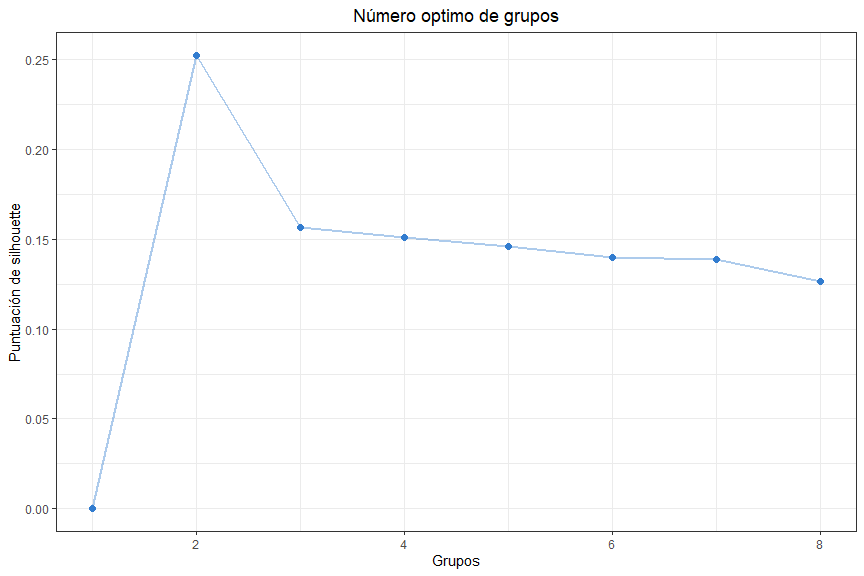

```r
data.frame(puntuacion = puntuacion_silhouette) %>%
    ggplot(., aes(x = 1:8, y = puntuacion))+
    geom_point(col = "#327CCF", size = 2)+
    geom_line(size = 1, col = "#327CCF", alpha = 0.4)+
    xlab("Grupos")+
    ylab("Puntuación de silhouette")+
    ggtitle("Número optimo de grupos")+
    theme_bw()+
    theme(plot.title = element_text(hjust = 0.5))
```

**Resultado:** Se prefiere el número de grupos con mayor puntuación de silhouette, en este caso se obtiene el óptimo con $K=2$.

## 3.3. Creación de grupos

Se procede con la creación de grupos utilizando la matriz proporcionada por la distancia de Gower y el valor de $K$ evidenciado en el paso anterior.

```r
#Se esetablece el K optimo
k <- 2

#Se utiliza el algoritmo pam para crear el agrupamiento
agrupamiento <- pam(
    #Se utiliza la ditancia de Gower
    distancia_gower,
    #Se indica que el argumento es una matriz de disimilitud
    diss = TRUE,
    #Se proporciona el número de grupos
    k)

#Se une el resultado del agrupamiento al conjunto de datos original
resultado_agrupamiento <- datos_originales %>%
    mutate(grupo = agrupamiento$clustering)
```

**Se muestra gráficamente el resultado del agrupamiento**

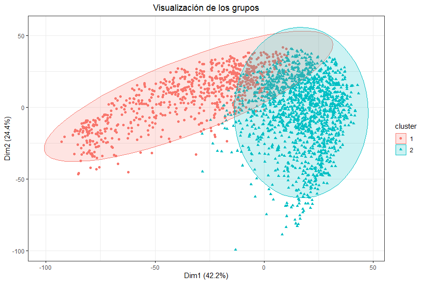

```r
clusters<-eclust(distancia_gower, "pam", k=2)
fviz_cluster(clusters, geom = "point", ellipse.type = "norm", ggtheme = theme_bw())+
    ggtitle("Visualización de los grupos")+
    theme(plot.title = element_text(hjust = 0.5))
```

## 3.4. Almacenamiento de resultados

Se almacena el resultado del agrupamiento para ser utilizado en el informe principal.

```r
write.csv(resultado_agrupamiento, file = "./datos/segmentacion.csv", row.names = TRUE)
```